# ST516: Computational Statistics Exam (Part A)

Katrine Eriksen and Katrine Bach

30 maj 2016

# Task 1

To begin with we will explain the theory behind the concepts that is needed.

### Correlation:

$E[X]$ is the expected value of the random variable $X$, this value is the weighted average of the possible values of $X$. The value of $E[X]$ does not say anything about the variantion of the these values. One way to measure this variance is to consider the average value of the squares of the difference between $X$ and $E[X]$.

**Definition:** If $X$ is a random variable with mean $\mu$, then the variance of $X$, denoted by $Var(X)$, is defined by
$$Var(X)=E[(X-\mu)^2]$$

The covariance between to random varibles can be defined by the following

**Definition:** The covariance of two random variables $X$ and $Y$, denoted $Cov(X,Y)$, is defined by
$$Cov(X,Y)=E[(X-\mu_x)(Y-\mu_y)]$$
where $\mu_x=E[X]$ and $\mu_y=E[Y]$.

The correlation between two random variables $X$ and $Y$, denoted as $Cor(X,Y)$, is defined by
$$Cor(X,Y)=\frac{Cov(X,Y)}{\sqrt{Var(X)Var(Y)}}$$

### Boostrap:

The Boostrapping Technique was developed by Efron in 1979 and was inspired by the Jacknife method which is a method especially useful for variance and bias estimation. The boostrap technique are a nonparametric Monte Carlo method that estimate the population distribution by resampling from an observed sample. The resampling method allows us to estimate population charachteristics and make inference about them. We use this method when the populations mean $\mu$ is unknown.

Suppose that $X_1,\dots,X_n$ are independent random variables that have a common distribution $F$. We are interested in using the variables to estimate some parameter $\theta(F)$ which could be the mean of $F$. Suppose further that an estimator of $\theta(F)$, where this estimator is called $g(X_1,\dots,X_n)$, has been proposed. In order to judge its worth as an estimator of $\theta(F)$ we are interested in estimationg its mean square error.
$$MSE(F)\equiv E_F[(g(X_1,\dots X_n)-\theta(F))^2]$$

As an immediate estimator of the above $MSE$ which is $S^2/n$ when $\theta=E[X_i]$ and $g(X_1,\dots,X_n)=\bar{X}$, it is not that obvious how it can be estimated otherwise. We therefore present the boostrap technique for estimation the mean square error. We first note that is the distribution function $F$ were known it would be possible to ompute the mean square error. Based on the observed data points $X_i$ it is possible to estimate the underlying distribution function $F$ by a so called empirical distribution function $F_e$
$$F_e(x)=\frac{\text{number of i:}X_i\leq x}{n}$$

If the empirical distribution function $F_e$ is close to $F$ which is should be in the case where $n$ is large. Then $\theta(F_e)$ probably be close to $\theta(F)$ when it is assumed that $\theta$ is a continous function of the distribution. The $MSE(F)$ should approximately be equal to
$$MSE(F_e)=E_{F_e}[(g(X_1,\dots,X_n)-\theta(F_e))^2]$$

In this expression the $X_i$ are to be regarded as being independent random variables having the distribution function $F_e$. This $MSE(F_e)$ is called the *Boostrap approximation to the mean square erroe $MSE(F)$*.

For the boostrap technique we can estimate the standard error by the following
$$\hat{se}=\sqrt{\frac{1}{N-1}\sum_{i=1}^{n}(\hat{x_i}-\bar{\hat{x}})^2}$$

To make the bootstrap estimate of the bias, we use the following
$$\text{bias}(\hat{\theta})=E[\hat{\theta}-\theta]=E[\hat{\theta}]-\theta$$
The simplest form of the confidence interval relies on the central limit theorem. This implies that it requires a large sample to be effective. It is assumed that $\hat{\theta}$ is unbiased and we have a normal distribution. Then $\theta$ is in the $Z$ interval
$$\hat{\theta}\pm \Phi^{-1}\bigg(1-\frac{\alpha}{2}\bigg)$$
$\alpha$ is the p-value and because we want a 95% confidence interval, then $\alpha$ should be $0.05$.

Now we use the explained theory above to write a function, that answer the questions giving in the task.

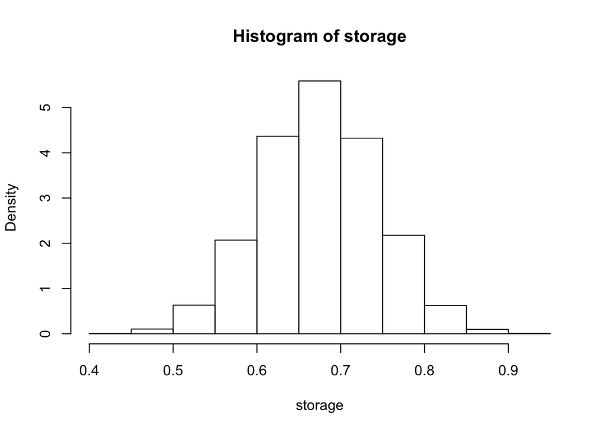

```
## $exact_corr
## [1] 0.6672733
##
## $boot_corr
## [1] 0.6754034
##
## $se
## [1] 0.06983729
##
## $bias
## [1] 0.008130169
##
## $confidence_interval
## [1] 0.8122820 0.5385249
```

```r
URL <- "https://raw.githubusercontent.com/haghish/ST516/master/data/sport.txt"
data <- read.table(URL, header = TRUE)
x <- data$Sport
y <- data$Grades

bootstrap <- function(n,x,y){
  #Warnings and stop
  if (n<0){stop("n must be bigger than zero")}

  #Calculation of the correlation between the variables og interest.
  theta.hat <- cor(x,y)

  #Standard Error
  set.seed(13)
  N <- nrow(data) # sample size (number of rows)
  storage <- numeric(n) #Store the variables
  for (i in 1:n) {
    k <- sample(1:N, size = N, replace = TRUE) # random indice
    storage[i] <- cor(x[k],y[k])
  }
  se <- sd(storage) #standard error
  hist(storage, probability = TRUE)

  #bias of sample correlation
  theta.hat.boot <- mean(storage)
  bias <- theta.hat.boot - theta.hat

  #95% confidence interval
  alfa = 0.05
  plus <- theta.hat.boot + qnorm(1-(alfa/2))*se
  minus <- theta.hat.boot - qnorm(1-(alfa/2))*se

  #return the above culculations
  return(list("exact_corr"=theta.hat,"boot_corr"=theta.hat.boot, "se"=se, "bias"=bias, "confidence_interval"=c(plus, minus)))
}


bootstrap(10000, x, y)
```

By using the R build-in function *cor* we found that the correlation between sport and grades are $cor(x,y)=0.6673$

From our function we see that the bootstrap estimate of correlation is $0.6754$. It is possible to see that the two values of correlation lies close to each other, hence the bootstrap method for estimating the correlation is valid. It should not be expected that these values are exactly the same, as the bootstrap method only approximate the correlation.

The standard error of bootstrap estimation is found by using the formula from the theory. We get the standard error of the bootsrap estimation is $0.0698$. This value can be interpreted as a measure of how good the approximation is. If the value is low this indicates that the approximation fits the observed values. On the other hand if the standard error is large the approximated values fits the observed values poorly. From this our standard error indicates that the bootstrap method approximate the values well, but there is still room for improvement.

The bias estimates the difference between the expected values of the approximation and the exact value. For a good approximation this implies that the diffence between the two values must be small. Our value is $0.0081$ which indicates that the estimator is close to being unbiased.

# Task 2

In this task we have to simulate two problems “Buffon’s Needle Problem” and “Lazzarini’s experiment”. First we want to explain the idea of “Buffon’s Needle Problem” and cover the theory we use.

### Buffon’s Needle Problem:

Buffon’s needle problem is a question that was first posed in the 18 th century by Georges-Luis Leclerc. The problem was the following. Suppose we have an infinit floor with parallel lines and we let $d$ be the distance between the lines on the floor. If we then drop a needle onto the floor, what is the probability that the needle will lie across a line? For solving this problem let the needle have a length $l$ with $y$ being the distance from the lower end of the needle to the nearest gridline above it. Further more $\theta$ measures the smallest clockwise angle form the gridirection to the needle. In the case where $l\leq d$, then the probability that the needle is crossing a line on the floor is
$$P(hit)=\frac{\int^{\pi}_0 l\sin\theta d\theta}{\pi d}=\frac{2l}{\pi d}\approx 0.6366$$
The needle hits one of the gridlines if and only iff $y<l\sin\theta$

### Monte Carlo:

Suppose we want to compute $\theta$ where
$$\theta=\int_0^1 g(x)dx$$
To compute the value of $\theta$ then we can express $\theta$ as
$$\theta= E[g(U)]$$
where U is uniformly distributed over (0,1) for which it follows that $g(U_1),\dots,g(U_n)$ are independant and identically distributed with the mean $\theta$. By the strong law of large numbers it follows that
$$\sum_{i=1}^n \frac{g(U_i)}{n}\rightarrow E[g(U)]=\theta \text{ as } n\rightarrow \infty$$
Hence it is possible to approximate $\theta$ by generating a large number of random numbers $u_i$ and taking as our approximation the avarge value of $g(u_i)$. This approach is called *the Monte Carlo* method.

In the case where we want to compute
$$\theta=\int_a^b g(x)dx$$
then by the use of substitution $y=\frac{x-a}{b-a}$, $dy=\frac{dx}{b-a}$ form which we can see that \begin{align*} \theta &= \int_0^1 g(a+(b-a)y)(b-a)dy\\ &= \int_0^1 h(y)dy \end{align*}

thus we can approximate $\theta$ by continually generating random numbers and then taking the average value of *h* evaluated at these random numbers.

In our case we can, by the use of the *Monte Carlo* method, write
$$\int^{\pi}_0 l\sin\theta d\theta$$
as
$$\frac{\sum_{i=1}^n f((b-a)*U_i+a)}{n}(b-a)$$

### Standard Deviation:

The standard deviation expresses how a stochastic variable is located around its mean value.
$$\sigma=\sqrt{E[(X-E[X])^2]}$$

### Standard Error:

The standard error is calculated by the use of the standard deviation $\sigma$. It is usually estimated by the standard deviation divided bu the square root of the sample size.
$$\text{se} = \frac{\sigma}{\sqrt(n)}$$

### Lazzarini’s experiment:

```r
#opgave 1
integralet <- 0
N <- 10000
l <- 1
d <- 1
# estimating the integration
for (i in 1:N) {
  a <- 0
  b <- pi
  U <- runif(N)
  theta <- (b-a)*U+a
  f <- l*sin(theta)
  integralet[i] <- sum((f/N))*(b-a) #the estiamtion
  Phit<- integralet[i]/(pi*d)
  pie <- (2*l)/(Phit*d)
}
#Variance
varians <- var(integralet)
print(paste("Variance:", varians))
```

```
## [1] "Variance: 9.52005514560212e-05"
```

```r
#Standard Deviation
deviation <- sd(integralet)
print(paste("Standard deviation:", deviation))
```

```
## [1] "Standard deviation: 0.00975707699344538"
```

```r
#Standard Error
error <- deviation/(sqrt(N))
print(paste("Standard Error:", error))
```

```
## [1] "Standard Error: 9.75707699344538e-05"
```

```r
#the 95% confidence interval
alfa = 0.05
plus <- integralet + qnorm(1-(alfa/2))*error
minus <- integralet - qnorm(1-(alfa/2))*error
print(c(mean(minus),mean(plus)))
```

```
## [1] 1.999896 2.000279
```

In subtask 2 we should estimate **P(hit)** by performing “Buffon’s Needle experiment”. To do this we write a function that takes 3 arguments (N,l,d) and return the estimated value $\pi$. We have been given that $N=10000$ and $l=d=1$

```r
#Opgave 2
buffon <- function(N,l,d){
  a <- 0
  b <- pi
  U <- runif(N)
  theta <- (b-a)*U+a
  f <- l*sin(theta)
  integralet <- sum((f/N))*(b-a) #the estiamtion
  Phit<- integralet/(pi*d)
  pie <- (2*l)/(Phit*d)
  return(pie)
}
buffon(10000,1,1)
```

```
## [1] 3.141183
```

Here we see that the estimated pi we get is pretty close to the actuel pi which is $3.14159265$. Obviously our estimate could be better, but we think it is an acceptable estimating of $\pi$.

In subtask 3 we have to repeat subtask 2 for values ranging from 1 to 10000 in intervals of 10. To do this we make a for-loop so we can se what the estimation for $pi$ is in every 10th interval.

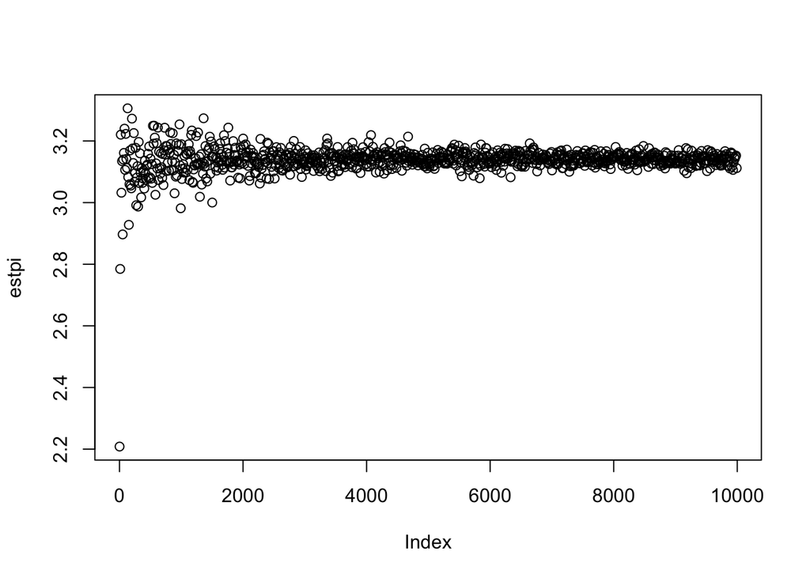

```r
#Opgave 3
estpi <- 0
for (i in seq(1, 10000, 10)) {
  estpi[i]<-buffon(i,1,1)
  #print(Task2(i,1,1))
}
plot(estpi)
```

From this plot we see that when N goes to infity then our estimation of $\pi$ goes towards the exact $pi$

The last subtask is about Lazzarini’s famous estimation of $pi$ using “Buffon’s Needle experiment”, which is accurate to the 6th decimal. We have to replicate his experiment a 10000 times where $N=3408$, $l=2.5$ and $d=3$, and compare them to our own results.

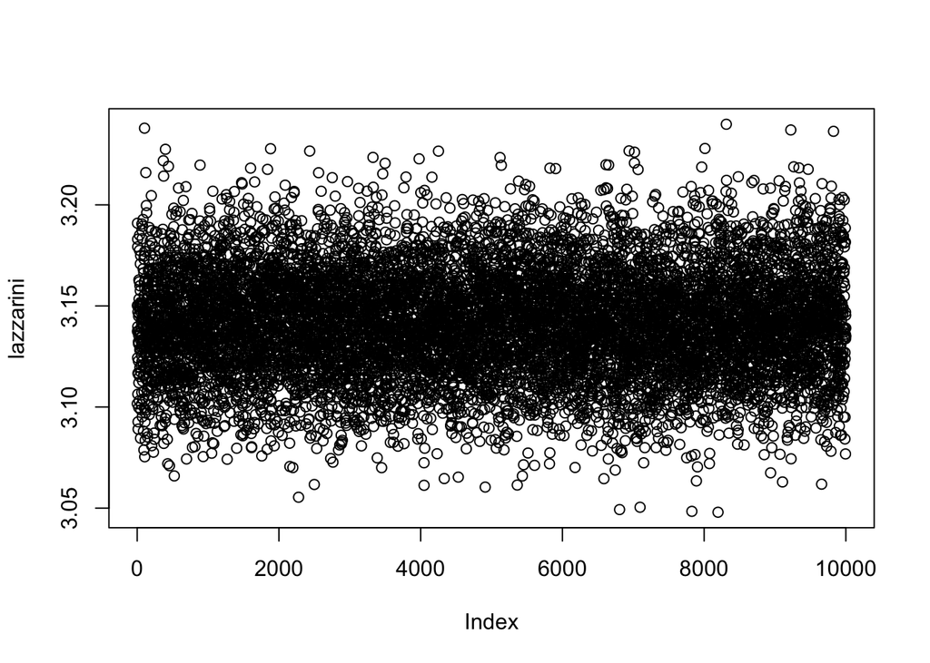

```r
#Opgave 4
lazzarini <- 0
for(i in seq(1,10000,1)){
  lazzarini[i] <- buffon(3408,2.5,3)
}
plot(lazzarini)
```

We think Lazzarini’s choice of N is a little inapproriate because of the fact that it seems to specific. It would be more reliable if there was some notes about the devitation of this number, because seems as if Lazzerina only chose this value because he aldready knew that he should get something like $\frac{355}{113}$ for running the eksperiment multiple times.

# Task 3

A company creates gum for children. These gums comes with a photo of a soccerplayer. Gitte has purchased 301 cards.

This task is about whether we reject or accept a p-value. Again we first start by explaining the teory we use, which is $chi^2$-distribution and Goodness of fit.

##### $\chi^2$-distribution:

In the case where $Y_i$ have normal independent distribution with mean $0$ and variance $1$ then $\chi^2$ distribution can be defined as
$$\chi^2=\sum_{i=1}^{df} Y_i^2$$
where $df$ is the *degree of freedom*. The *degree og freedom* is the number of parameters which may be independently varied minus $1$

##### Goodness of fit:

The idea of the Pearson chi-square test is to compare the observed sample points with the expected sample points. The hypothesis $H_0$ is rejected if the observed and expected numbers are too different.

We let $N_j$ denote the observed number of sample points in $A_j$
$$N_j=\sum_{i=0}^n I_{A_j}(X_i)$$
The expected number under $H_0$ is given by:
$$E_{H_0}=\sum_{i=1}^n E_{H_0}{I_{A_j}(X_i)}=nP_{H_0}(X_i\in A_j)$$
The Pearson chi-square statistic combine $N_j$ and $E_{H_0}$ into a single expression in the following way
$$\chi^2=\sum_{j=1}^k \frac{(N_j-E_{H_0}(N_j))^2}{E_{H_0}(N_j)}$$
We reject $H_0$ when the observed value of $\chi^2$ is too large.

The p-value gives the probability of obtaining an outcome that is more extreme than the observed one if $H_0$ is true
$$p-value=P(\chi^2_{k-r-1}>\chi^2_{obs})$$
where $\chi^2_{k-r-1}$ is denoting a chi-square random variables with $k-r-1$ degrees of freedom. We reject $H_0$ if the p-value$<\alpha$.

In the first subtask we have to write a function that applies the Monte Carlo method and generate a $\chi^2$ distribution. The function we make should return the probability that the $\chi^2$ distribution is larger than the value x.

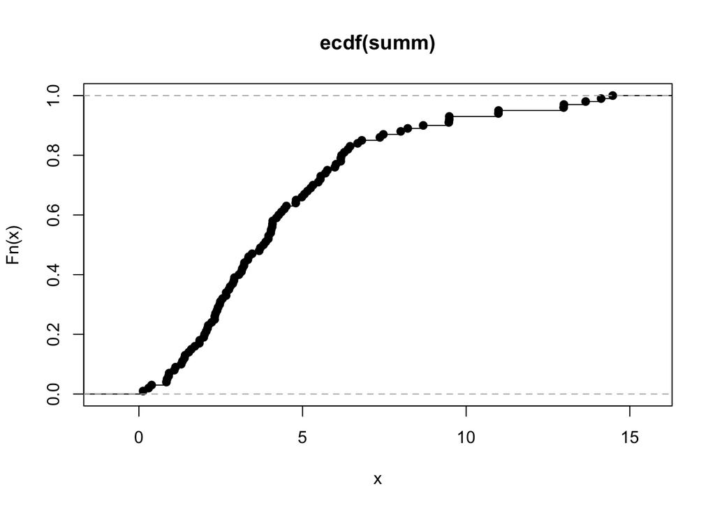

```
## [1] 0.07
```

```r
chi.probability <-function(x, df, n){
set.seed(13)
summ <- 0
Y <- 0
  for (i in 1:df) {
    Y <- rnorm(n, mean=0, sd=1)
    Yianden <- Y^2
    summ <- summ + Yianden
  }
blup <- ecdf(summ)
plot(blup)
p <-1-blup(x)
return(p)

}
chi.probability(10,4,100)
```

In the second subtask we have to write a function that takes two variables (x,p). This function should return the $\chi^2$ goodness of fit value.

```r
GoodnessOfFit <- function(x,p=c(rep(1/length(x),length(x)))){
  set.seed(13)
  n<-301
  Exp<-n*p
  Pearson<-((x-Exp)^2/Exp)
  GOF<-sum(Pearson,na.rm = FALSE)
  return(GOF)
}
```

For the fourth subtask the company aclaims that all cards are equally likely to get in any shop. For validating this we make the following $H_0$ together with $H_1$ :

$H_0$: It is equally likely to get each of the different cards, this implies that the probability for getting each card is $1/20$. Because the company claims that all cards are equally likely to get in any shop, since there a 20 different cards this implicates that the probability for getting each card is $1/20$

$H_1$: It is not equally likely to get each of the different cards. This is just the opposite of our nul-hypothesis, so the H1-hypothesis implies that the probability for getting each card is not $1/20$.

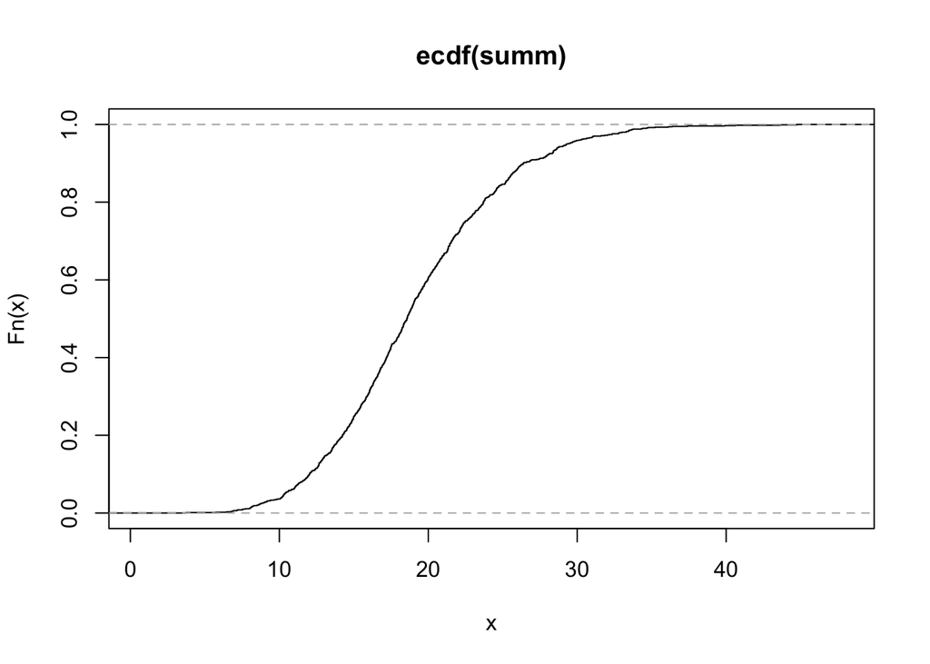

```
## [1] 0
```

```r
URL <- "https://raw.githubusercontent.com/haghish/ST516/master/data/soccer.txt"
data <- read.table(URL, header = TRUE)
x<-data$Number
GOFit<-GoodnessOfFit(x)
chi.probability(GOFit,length(x)-1,1000)
```

It can be seen that the p-value is zero. By interpreting this value the null-hypothesis can be rejected. Hence all cards are not equally distributed. This is also consistent with the observed values from Gitte.

For subtask five we want to show the difference between the $\chi^2$ provided by *R* in contrast to the function for $\chi^2$ by Monte Carlo made in one of the previous subtasks.

```r
1-pchisq(GOFit,length(x)-1)
```

```
## [1] 1.257277e-08
```

It can be seen that these two p-values are not the same. Eventhough these values are not the same, they both reach the same conclusion that the $H_0$ hypothesis must be rejected. The difference is that the build-in function within *R* calculates the intregral numerically, while our function only makes an approximation of the integral using the Monte Carlo method.

The $P(\chi^2>x$ can be used to obtain the p-value, because this calculates the upper tail of the distribution.

Since the model is a chi-squared Goodness of fit test the chi-square distribution is used to evaluate the observed data. The chi-squared distribution is used to find the lower tail, which is the sum of probability until x. The probability that $\chi^2>x$ is then 1 minus the lower tail.

The p-value indicates how good the observed data fits the distribution. If the p-value is low this indicate that the obsereved data is unlikeli according to the null-hypothesis, which implies that the null-hypothesis must be wrong, hence it is rejected.

In subtask 7 we assume that Gittes friend collects a large number of cards and calculates the probability of obtaining each player’s card. We will make use of our functions *chi.probability* and *GoodnessOfFit* to check if Gitte’s cards fit the expected distribution. This implies that the null-hypothesis in this case is that Gitte’s cards fits the expected distribution calculated by her friend.

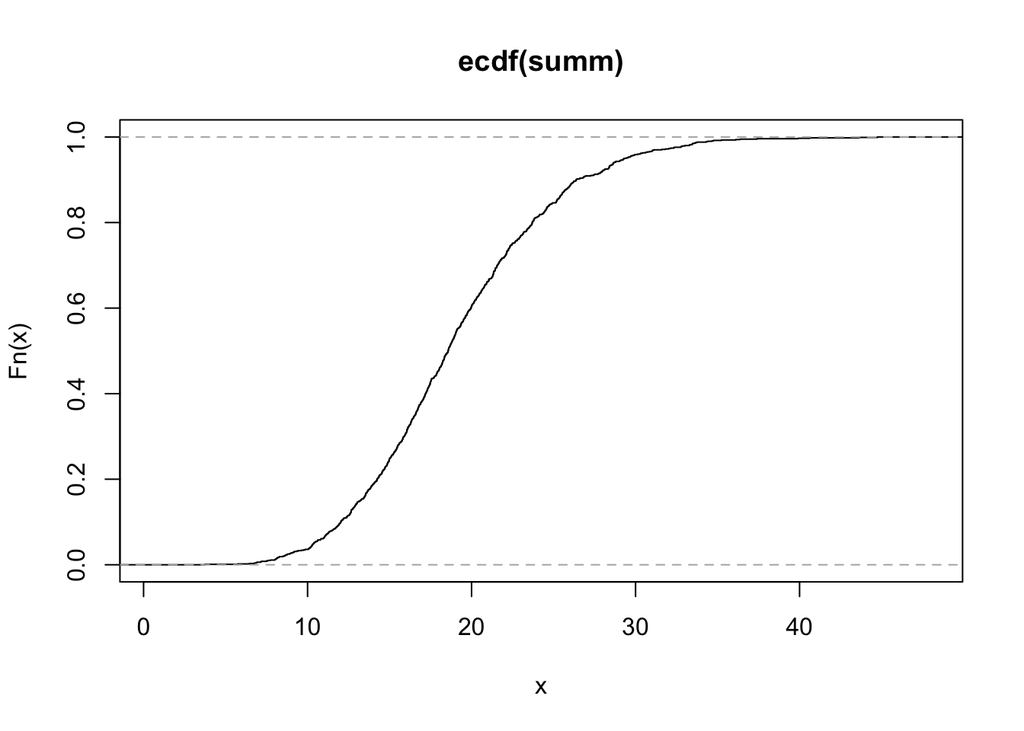

```
## [1] 0.127
```

```r
URL <- "https://raw.githubusercontent.com/haghish/ST516/master/data/soccer.txt"
data <- read.table(URL, header = TRUE)
x<-data$Number
p<-data$expected
GOFit<-GoodnessOfFit(x,p)
chi.probability(GOFit,length(x)-1,1000)
```

By looking at the output it can be seen that the expected distribution calculated by Gitte’s friend fits the distribution of Gitte’s cards better than the claim from the company. It can be seen from the p-value in this case that the null-hypothesis is not rejected.